# 시각화 (Visualize)

책의 첫 번째 파트를 읽고 난 후, 여러분은 데이터 과학을 수행하기 위한 가장 중요한 도구들을 (적어도 표면적으로는) 이해하게 되었습니다. 이제 세부 사항으로 깊이 들어갈 때입니다. 책의 이 파트에서는 데이터 시각화에 대해 더 깊이 있게 배울 것입니다.

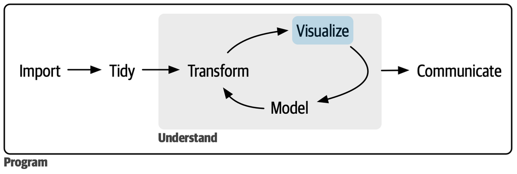

Figure 1: 데이터 시각화는 종종 데이터 탐색의 첫 번째 단계입니다.

각 장은 데이터 시각화를 생성하는 한두 가지 측면을 다룹니다.

- 9 레이어(Layers) 에서는 레이어드 그래픽 문법(layered grammar of graphics)에 대해 배웁니다.
- 10 탐색적 데이터 분석(Exploratory data analysis) 에서는 시각화를 호기심 및 회의주의와 결합하여 데이터에 대한 흥미로운 질문을 던지고 답하는 방법을 배웁니다.
- 마지막으로 11 소통(Communication) 에서는 탐색적 그래픽을 가져와 이를 발전시켜 설명적 그래픽으로 바꾸는 방법을 배웁니다. 설명적 그래픽은 분석을 처음 접하는 사람이 무슨 일이 일어나고 있는지 가능한 한 쉽고 빠르게 이해할 수 있도록 돕는 그래픽입니다.

이 세 장은 여러분을 시각화의 세계로 안내하지만, 배워야 할 것이 훨씬 더 많습니다. 더 배우기에 가장 좋은 곳은 ggplot2 책인 [*ggplot2: Elegant graphics for data analysis*](https://ggplot2-book.org/)입니다. 이 책은 기저 이론을 훨씬 더 깊이 있게 다루며, 실질적인 문제를 해결하기 위해 개별 조각들을 결합하는 더 많은 예제를 담고 있습니다. 또 다른 훌륭한 리소스는 ggplot2 확장 갤러리 https://exts.ggplot2.tidyverse.org/gallery/입니다. 이 사이트에는 새로운 지옴(geoms)과 스케일(scales)로 ggplot2를 확장하는 많은 패키지들이 나열되어 있습니다. ggplot2로 하기에 어려워 보이는 작업을 하려 할 때 시작하기 좋은 곳입니다.